# emileygz_OriginalHomeworkCode_04

Emiley Garcia-Zych

2023-10-30

```r
library(ggplot2) #load the necessary packages
library(curl)
```

# Homework 4: What’s Your Malfunction?

## Emiley Garcia-Zych

1. Write a simple R function, Z.prop.test(), that can perform one- or two- sample Z tests for proportion data, using the following guidelines.

```r
Z.prop.test <- function(p1, n1, p2 = NULL, n2 = NULL, p0, alternative = "two.sided", conf.level = 0.95) { # defines a new fucntion "Z.prop.test()" that takes the arguments "p1" and "p2", sample sizes "n1" and "n2", null hypothesis proportion "p0", the type of test, and confidence level of 95%. If p2 and n2 are not provided, the test will be able to run a one-sample test.

  one_sample_test <- is.null(p2) || is.null(n2) # Checks if either p2 or n2 is NULL to determine one-sample or two-sample test

  # Calculate the estimated proportion in a two-sample case
  if (one_sample_test) {
    p1_hat <- p1
  }
  else {
    p1_hat <- p1
    p2_hat <- p2
  }

  # Check rules of thumb
  if (n1 * p1_hat > 5 && n1 * (1 - p1_hat) > 5 && (one_sample_test || (n2 * p2_hat > 5 && n2 * (1 - p2_hat) > 5))) { ##makes sure both samples are large enough to run the tests.
    standard_error <- sqrt(p1_hat * (1 - p1_hat) / n1) # Calculate the standard error

    if (!one_sample_test) { #checks to see if it is a two-sample test. If it is a one-sample test, it continues to the else...
      standard_error2 <- sqrt(p2_hat * (1 - p2_hat) / n2)
      pooled_standard_error <- sqrt((standard_error^2 / n1) + (standard_error2^2 / n2))
      Z_score <- (p1_hat - p2_hat) / pooled_standard_error ##calculates Z statistic
    }
    else {
      Z_score <- (p1_hat - p0) / standard_error
    }

    if (alternative == "greater") {
      P <- 1 - pnorm(Z)
    } else if (alternative == "less") {
      P <- pnorm(Z)
    } else {
      P <- 2 * (1 - pnorm(abs(Z)))
    }

    # Calculate the confidence interval
    alpha <- 1 - conf.level
    if (one_sample_test) {
      margin_of_error <- qnorm(1 - alpha / 2) * standard_error
      CI <- c(p1_hat - margin_of_error, p1_hat + margin_of_error)
    } else {
      margin_of_error <- qnorm(1 - alpha / 2) * pooled_standard_error
      CI <- c(p1_hat - p2_hat - margin_of_error, p1_hat - p2_hat + margin_of_error)
    }

    result <- list(Z = Z, P = P, CI = CI)
    return(result)
  } else { ##returns a warning and lets the user know there was some issue with the data.
    warning("The rules of thumb (n*p > 5 and n*(1-p) > 5) are violated. The results may not be valid.")
    return(NULL)
  }
}
```

2. The dataset from Kamilar and Cooper has in it a large number of variables related to life history and body size. For this exercise, the end aim is to fit a simple linear regression model to predict longevity (MaxLongevity_m) measured in months from species’ brain size (Brain_Size_Species_Mean) measured in grams. Do the following for both longevity~brain size and log(longevity)~log(brain size):

```r
k_and_c <- curl("https://raw.githubusercontent.com/fuzzyatelin/fuzzyatelin.github.io/master/AN588_Fall23/KamilarAndCooperData.csv")
d <- read.csv(k_and_c, header = TRUE, stringsAsFactors = FALSE)
d
```

[output not shown]

[output cut: 2767 more lines]

```r
is.atomic(d) ## I was having trouble and kept running into the atomic value error.
```

```
## [1] FALSE
```

```r
getElement(d, 'MaxLongevity_m')
```

```
##   [1] 276.00     NA     NA 243.60     NA 300.00 240.00 300.00 360.00     NA
##  [11] 405.60     NA     NA 303.60 265.20 156.00 336.00 552.00 327.60 453.60
##  [21]     NA     NA     NA 492.00 324.00 216.00 300.00     NA 303.60     NA
##  [31]     NA 214.80 201.60     NA 211.20 180.00 201.60 240.00 184.80 181.20
##  [41] 528.00 541.20 657.60 492.00     NA 372.00 252.00 360.00 321.60     NA
##  [51] 339.60 396.00 276.00 447.60     NA 343.20 192.00 325.20 360.00 315.60
##  [61] 276.00 228.00 289.20 312.00     NA     NA 180.00 231.60 235.20 369.60
##  [71]     NA     NA 423.60 294.00 366.00     NA     NA 291.60 286.80     NA
##  [81]     NA     NA 220.80 444.00 360.00 360.00 240.00     NA     NA 180.00
##  [91]     NA 198.00 204.00 168.00     NA     NA 648.00     NA 205.20     NA
## [101] 144.00 528.00 444.00 480.00 540.00 684.00 432.00     NA 360.00 360.00
## [111] 255.60 214.80 297.60     NA     NA 103.00     NA 144.00     NA 392.40
## [121] 321.60     NA 196.80 350.40 376.80     NA 456.00 396.00     NA 432.00
## [131] 411.60 408.00 348.00 360.00 480.00 420.00 264.00     NA 400.80 555.96
## [141] 186.00     NA 144.00 370.80 183.60 252.00 529.20     NA     NA     NA
## [151] 318.00 205.20 225.60 204.00 576.00 720.00 302.40 540.00 450.00 540.00
## [161] 312.00 144.00     NA     NA     NA     NA     NA     NA 248.40     NA
## [171] 720.00     NA 192.00     NA     NA     NA     NA     NA 240.00 247.20
## [181] 300.00     NA     NA 354.00 228.00 294.00 246.00 242.40 182.40 184.80
## [191] 240.00     NA 277.20     NA 363.60     NA 324.00 300.00 456.00 144.00
## [201]     NA 180.00 336.00 373.20 373.20     NA 408.00 300.00 339.60 302.40
## [211] 276.00     NA 384.00
```

1. Fit the regression model and, using {ggplot2}, produce a scatterplot with the fitted line superimposed upon the data. Append the the fitted model equation to your plot (HINT: use the function geom_text()).

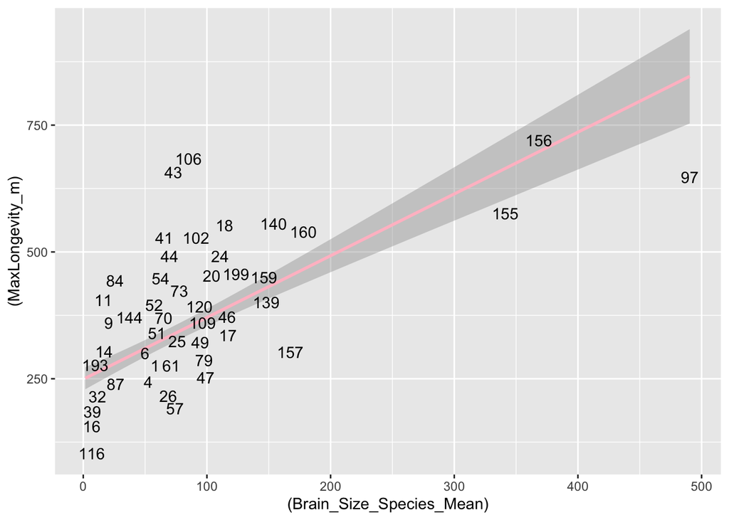

```r
library(ggplot2)

# Fit longevity~brain size model
model1 <- lm(MaxLongevity_m ~ Brain_Size_Species_Mean, data = d)

plot1 <- ggplot(d, aes((Brain_Size_Species_Mean), (MaxLongevity_m), label = rownames(d))) + geom_smooth(method = "lm", formula = y ~ x, color = "pink")
plot1 + geom_text(check_overlap = TRUE)
```

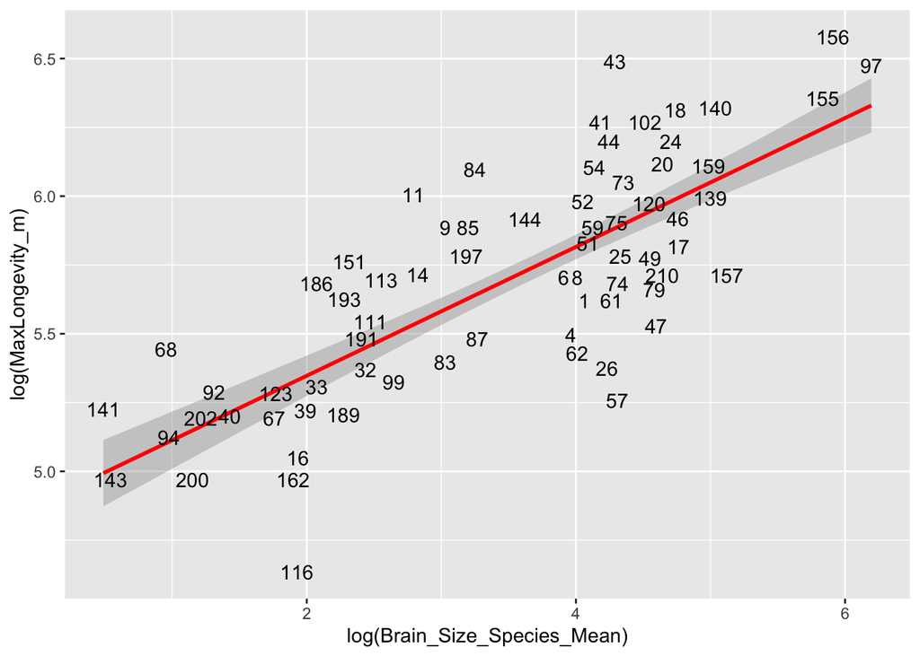

```r
# Fit log(longevity)~log(brain size) model
model2 <- lm(log(MaxLongevity_m) ~ log(Brain_Size_Species_Mean), data = d)

plot2 <- ggplot(d, aes(log(Brain_Size_Species_Mean), log(MaxLongevity_m), label = rownames(d)))+ geom_smooth(method = "lm", formula = y ~ x, color = "red")

plot2 + geom_text(check_overlap = TRUE)
```

2. Identify and interpret the point estimate of the slope (β1), as well as the outcome of the test associated with the hypotheses H0: β1 = 0; HA: β1 ≠ 0. Also, find a 90 percent CI for the slope (β1) parameter.

```r
summary(model1)
```

```
##
## Call:
## lm(formula = MaxLongevity_m ~ Brain_Size_Species_Mean, data = d)
##
## Residuals:
##     Min      1Q  Median      3Q     Max
## -198.27  -61.92  -17.78   56.16  331.36
##
## Coefficients:
##                         Estimate Std. Error t value Pr(>|t|)
## (Intercept)             248.9523    11.1111   22.41   <2e-16 ***
## Brain_Size_Species_Mean   1.2180     0.1101   11.06   <2e-16 ***
## ---
## Signif. codes:  0 '***' 0.001 '**' 0.01 '*' 0.05 '.' 0.1 ' ' 1
##
## Residual standard error: 90.91 on 126 degrees of freedom
##   (85 observations deleted due to missingness)
## Multiple R-squared:  0.4928, Adjusted R-squared:  0.4887
## F-statistic: 122.4 on 1 and 126 DF,  p-value: < 2.2e-16
```

Model 1 B1 = Brain_Size_Species_Mean = 1.2180

Model 2 B1 = log(d$Brain_Size_Species_Mean) = 0.23415

We accept the alternative hypothesis.

3. Using your model, add lines for the 90 percent confidence and prediction interval bands on the plot and add a legend to differentiate between the lines.

```r
##confint(model1, level = 0.9)
##confint(model2, level = 0.9)

pi1 <- predict(model1, newdata = data.frame(Brain_Size_Species_Mean = 800), interval = "prediction", level = 0.90)
head(pi1)
```

```
##        fit      lwr      upr
## 1 1223.345 1021.805 1424.884
```

```r
##pi2 <- predict(model2, newdata=data.frame(Brain_Size_Species_Mean), ##interval = "prediction", level = 0.90)
##head(pi2)
```

4. Produce a point estimate and associated 90 percent PI for the longevity of a species whose brain weight is 800 gm. Do you trust the model to predict observations accurately for this value of the explanatory variable? Why or why not?

```r
# Predict longevity for species with brain weight of 800 gm using the first model

new_data <- data.frame(Brain_Size_Species_Mean = 800)
predicted_longevity <- predict(model1, newdata = new_data)

# 90% prediction interval
pi <- predict(model1, newdata = new_data, interval = "prediction", level = 0.9)

print("Predicted Longevity:")
```

```
## [1] "Predicted Longevity:"
```

```r
print(predicted_longevity)
```

```
##        1
## 1223.345
```

```r
print("90% Prediction Interval:")
```

```
## [1] "90% Prediction Interval:"
```

```r
print(pi)
```

```
##        fit      lwr      upr
## 1 1223.345 1021.805 1424.884
```